# Project Group 10 – Rail Sabotage and Road Traffic on the A1

Did the railway disruptions of 15 September 2026 change road traffic on the A1 between Amersfoort, Apeldoorn and Deventer?

Members: Lars van Manen, Jente van den Berg, Vigo Groenewold, Sipke de Jong, Jasper Steenvoorden

TIL6022 TIL Python Programming – Final project

# Motivation and introduction

Rail and road transport networks are closely interconnected. When railway services are disrupted, travellers may choose alternative modes of transport, change their route, or cancel their trip altogether. As a result, railway disruptions can increase pressure on parts of the road network (Huang & Loo, 2023).

The railwayline between Amersfoort, Apeldoorn and Deventer links the Randstad to the eastern Netherlands, and its services are regularly disrupted. On 15 September 2026 (Prinsjesdag), objects deliberately placed on the tracks at 35 or more locations caused disruptions to train traffic in the centre and east of the country (NOS, 2026). The Amersfoort–Deventer corridor was disrupted too; that evening, another obstruction near Teuge halted trains between Apeldoorn and Deventer (NOS, 2026).

While the direct effects of the railway disruptions were widely reported (NOS, 2026), their potential impact on road traffic remains unclear. This project investigates whether the railway disruptions of 15 September 2026 were associated with measurable changes in traffic conditions on the A1 corridor between Amersfoort, Apeldoorn and Deventer. NDW traffic data will be used to compare traffic intensity and average vehicle speed on the disruption day with those on comparable Tuesdays.

# Research Objective

**Research question**

To what extent did the railway disruptions on the Amersfoort–Apeldoorn–Deventer corridor on 15 September 2026 lead to measurable changes in road traffic intensity and average vehicle speed on the parallel A1 corridor?

**Objectives**

- Construct a baseline traffic profile for the A1 between Amersfoort and Deventer from historical NDW measurements.
- Quantify how traffic intensity and average speed on 15 September 2026 deviated from that profile, per location, direction and hour.
- Quantify the severity of the rail disruptions on the Amersfoort–Apeldoorn–Deventer corridor using train service cancellation data.
- Determine whether the deviations in traffic intensity and average speed coincide in time and place with the rail disruptions.

Understanding how the road network responds to rail disruptions may help road authorities such as Rijkswaterstaat anticipate and manage the wider impacts of future disruptions. The findings may also contribute to a better understanding of the interaction between rail and road transport networks.

# Contribution Statement

**Lars van Manen**:

- Motivation and introduction; setting up the Jupyter notebook and GitHub repository.

**Jente van den Berg**:

- Searching for data sources; introduction and objectives.
- Quantifying the severity of rail disruptions and creating related visualizations and interpretation of this.
- Writing the discussion

**Vigo Groenewold**:

- Describing and specifying the data pipeline.
- Interpretation and analysis of visualized data, and writing a conclusion.

**Sipke de Jong**:

- Outline of the code structure; selecting measurement and time periods, checking coherence of proposal.
- Visualizations of traffic speed and intensity.

**Jasper Steenvoorden**:

- Searching for data sources; selecting measurement and time periods.
- Structure of final report.

# Geographical and temporal scale

**Geographical scale**: The A1 motorway between Amersfoort, Apeldoorn and Deventer, which runs parallel to the disrupted railway. NDW measurement locations are selected along this section, in both driving directions and at several points along the corridor. The disrupted railway between the stations Amersfoort Centraal, Deventer and Apeldoorn.

**Temporal scale**: The disruption day, Tuesday 15 September 2026, analysed per hour. The baseline consists of the three Tuesdays before and the three Tuesdays after the disruption day.

# Data Sources

## NDW Dexter

*NDW Dexter* (n.d.): https://dexter.ndw.nu/opendata/overview

The NDW (Nationaal Dataportaal Wegverkeer, or National Data Portal Road Traffic) makes mobility data reliant, accessible and useful. The institution does this together with governmental partners such as Rijkswaterstaat, the Dutch provinces and Dutch municipalities. Moreover, the institution publishes multiple types of data through several applications. For this project, the Dexter application will be used as a data source.

Dexter allows the user to select a timeframe of up to 366 days with the possibility to filter on each day of the week as well as specific measurement locations. After configuration, Dexter delivers a report containing the average number of vehicles counted in every hour of the day and the average speed during every hour of the day. If multiple days are selected, the average over all selected days is given. An example of the data obtained from Dexter is shown in Table 1. Several locations will be studied to find out whether the train disruptions on 15 September had any effect on the measured variables.

| Hour of the day | Intensity (vehicles/hour) | Average speed (km/h) |
| --- | --- | --- |
| 00:00 – 00:59 | 39.9 | 93 |
| 01:00 – 01:59 | 50.9 | 91 |
| 02:00 – 02:59 | 50.7 | 92 |

*Table 1: Average intensity and speed per hour from 2025-09-01 to 2025-09-30 on weekdays, for measurement location 0151hrl0263ra (RWS01_MONIBAS_0151hrl0263ra), exported from Dexter.*

## Selecting Data

To address the research question, data from Dexter, specifically concerning the A1 highway, will be extracted and grouped. Along the A1 highway, there are 776 data collections points in the regions Amersfoort, Barneveld, Apeldoorn, Voorst, and Deventer. These points are of interest because they lie in the area that was affected by the disruptions in the railway network. Out of these points, several points need to be selected. Points directly in front of and also direcly after junctions will be chosen as points of interest. This is because these give a good representation of the amount of cars leaving and entering the highway at that junction.

| Location | Datapoints |
| --- | --- |
| A1 Re 43.6 (Before Junction Hoevelaken) | RWS01_MONICA_00D00106CC55D007000B RWS01_MONICA_00D00106CC55D0070007 RWS01_MONICA_00D00106CC55D0070087 RWS01_MONICA_00D00106CC55D007008B |
| A1 Re 46.4 (After Junction Hoevelaken) | RWS01_MONICA_10D00107400FD007000B RWS01_MONICA_00D00106CC55D0070007 RWS01_MONICA_10D00107400FD0070187 |
| A1 Re 86.5 (Before Junction Beekbergen) | RWS01_MONICA_00D0010D840AD007008B RWS01_MONICA_00D0010D840AD0070087 RWS01_MONICA_00D0010D840AD007000F RWS01_MONICA_00D0010D840AD007000B RWS01_MONICA_00D0010D840AD0070007 |
| A1 Re 90.5 (After Connection N345) | RWS01_MONICA_00D0010E243CD0070007 RWS01_MONICA_00D0010E243CD007000B RWS01_MONICA_00D0010E243CD007000F RWS01_MONICA_00D0010E243CD0070013 RWS01_MONICA_00D0010E243CD0070017 |
| A1 Re 104.4 (Before Connection N348) | RWS01_MONIBAS_0011hrr1044ra |
| A1 Re 107.7 (After Connection N348) | RWS01_MONIBAS_0011hrr1076ra |

Table 2: Data points before and after important junctions on the A1 highway in eastward direction in the research area

| Location | Datapoints |
| --- | --- |
| A1 Li 107.6 (Before Connection N348) | RWS01_MONIBAS_0011hrl1076ra |
| A1 Li 98.7 (After Connection N348) | RWS01_MONIBAS_0011hrl0987ra |
| A1 Li 90.6 (Before Connection N345) | RWS01_MONICA_00D0010E2432D0050089 RWS01_MONICA_00D0010E2432D0050085 RWS01_MONICA_00D0010E2432D0050005 RWS01_MONICA_00D0010E2432D005000D RWS01_MONICA_00D0010E2432D0050009 RWS01_MONIBAS_0011hrl0905ra |
| A1 Li 85.6 (After Junction Beekbergen) | RWS01_MONIBAS_0011hrl0856ra |
| A1 Li 46.0 (Before Junction Hoevelaken) | RWS01_MONIBAS_0011hrl0460ra |
| A1 Li 43.4 (After Junction Hoevelaken) | RWS01_MONIBAS_0011hrl0434ra |

Table 3: Data points before and after important junctions on the A1 highway in westward direction in the research area

Apart from the measurement locations, a relevant time period must be selected that accurately depicts what the expected car traffic on the A1 would have been on September 15 2026.

It is commonly known that car traffic varies based on the day of the week(CROW,2022). Since September 15 2026 was a Tuesday, this study will focus on Tuesdays. Moreover, to minimize macroeconomic confounding trends and seasonality, the study will more specifically focus on Tuesdays up to 3 weeks prior and 3 weeks after September 15 2026.

## Rijden de Treinen Open Data

Rijden de Treinen. (n.d.). Open Data: Train services dataset. Retrieved from https://www.rijdendetreinen.nl/open-data/treinarchief#downloads

To quantify the severity of the railway disruptions, train service data from Rijden de Treinen was used. The dataset contains information on scheduled train services, cancellations and delays at individual stations. For this study, only long-distance passenger services calling at Amersfoort Centraal, Apeldoorn and Deventer were considered.

Local stopping services and replacement buses were excluded because the objective is to analyse disruptions affecting travellers who are most likely to use the A1 corridor as an alternative.

# Data pipeline

The data analysis pipeline will be used to determine whether the railway disruption on 15 September 2026 resulted in measurable changes in road traffic along the A1 corridor between Amersfoort, Apeldoorn and Deventer. Historical traffic measurements from NDW Dexter will be used to compare the disruption day with normal traffic conditions.

### 1. Data collection

Traffic data will be collected from several NDW measurement locations along the A1 between Amersfoort, Apeldoorn and Deventer. Where possible, measurement points in both driving directions and at multiple locations along the corridor will be included.

For each measurement point, the main variables are:

- traffic intensity in vehicles per hour;
- average vehicle speed in km/h;
- measurement location and direction;
- time of day.

The disruption day, Tuesday 15 September 2026, will be analysed separately. To construct a representative baseline, the reference dataset will consist of all Tuesdays up to 3 week prior and 3 weeks after the disruption day.

In addition, train service data will be obtained from the Rijden de Treinen Open Data archive. The dataset contains information on scheduled train services, cancellations and delays at individual stations.

### 2. Data cleaning and pre-processing

The NDW datasets will be imported into Python and converted into a consistent format. Measurements from the different locations and dates will be combined into one dataset containing location, direction, date, time, traffic intensity and average speed.

Missing or technically unreliable measurements will be identified and removed where necessary. The reference data will then be filtered so that only eligible Tuesdays outside school holidays remain. Measurements will be aggregated into consistent hourly time intervals, allowing the disruption day and the baseline to be compared directly.

Train service records will be filtered to include only services calling at Amersfoort Centraal, Apeldoorn and Deventer. Furthermore, only long-distance passenger train categories (Intercity, Intercity Direct, ICE and Sneltrein) will be retained. For each service, the planned operating hour and disruption status will be extracted.

### 3. Baseline construction

For each measurement location, direction and hour of the day, the traffic measurements of all selected reference Tuesdays will be combined to create a normal traffic profile.

The mean traffic intensity and mean vehicle speed will be calculated for each hourly interval. This produces an expected value for the 15th of September.

For the railway data, a baseline will be constructed using the three Tuesdays before and the three Tuesdays after the disruption day. The average number of affected train services per hour will be calculated, providing a reference level of normal operational disturbances against which the disruption day can be compared.

### 4. Comparative analysis

Traffic conditions on 15 September 2026 will be compared with the baseline for the same location, direction and hour. For traffic intensity, both the absolute and the relative difference will be calculated:

$$\Delta I = I_{\text{disruption}} - I_{\text{baseline}}$$

*Formula 1: absolute difference in traffic intensity*

$$\%\Delta I = \frac{I_{\text{disruption}} - I_{\text{baseline}}}{I_{\text{baseline}}} \times 100$$

*Formula 2: relative difference in traffic intensity*

The same calculations will be performed for average vehicle speed.

A higher-than-normal traffic intensity may indicate additional road demand during the rail disruption, while a decrease in average speed may indicate additional congestion. Both variables will therefore be analysed together.

For train services, a service is classified as affected when it is either fully cancelled or partially cancelled. The number of affected services per hour on 15 September 2026 will be compared with the baseline level of affected services on comparable Tuesdays.

### 5. Spatial and temporal analysis

The calculated differences will be compared across locations and throughout the day. This makes it possible to investigate both when abnormal traffic conditions occurred and where along the corridor the largest deviations were observed.

Particular attention will be given to the time periods in which rail services were disrupted. The railway analysis makes it possible to identify when disruption levels were highest and whether these periods coincide with deviations in traffic intensity or average speed on the A1 corridor.

### 6. Visualization and interpretation

The results will be visualized using:

- time-series plots comparing traffic conditions on the disruption day with the normal Tuesday baseline;
- plots of the percentage change in traffic intensity and average speed;
- a comparison of affected train services on the disruption day and the train disruption baseline;
- comparisons between different measurement locations and directions.

These visualizations will be used to assess whether road traffic on 15 September differed systematically from typical Tuesday traffic and whether these differences coincide with the railway disruption.

# Key Visualizations and Code Build-Up

### Traffic speed and intensity

To visualize whether there has been a significant difference in traffic on the A1 highway, a python script has been made that follows 4 steps:

- In step 0 the filepaths for the data files are fetched.
- In step 1, the get_location_data_function function obtains the necessary data from the CSV files, this data consists of the hour-of-the-day, the traffic intensity of the specified hour and the average speed at the specified hour. The function reads the CSV files and converts them to dataframes. For some locations the traffic intensity and speed are already an aggregate of multiple sensors and can be directly passed to the dataframe. However, some locations have multiple measurement points and first need to be averaged before being passed to the dataframe. This function returns the data in a dictionary.
- In step 2, the function plot_direction is created which first loads the data using the get_location_data function and secondly calculates the expected values by simply taking the average of the three weeks prior and the three weeks after.
- Next up in step 3, the plot_direction function creates a 2x2 grid to plot the four graphs. At [0.0] and [0,1] the respective baseline traffic intensity and baseline average speed are plotted to give an identification how much variance there is between the weeks prior and the weeks after. This also makes it easy to observe any weird outliers in the data that have not been taking out in the initial data filtering. At [1,0] and [1,1] on the grid, the expected values for the traffic intensity and speed are plotted against the real values. In these two graphs any serious deviations between the expected and real values can be a consqequence of the train disruption, if this deviation can also be matched within a reasonable time period of the train disruptions.

### Railway disruption analysis

To quantify the severity of the railway disruptions, a separate Python script was developed that follows three main steps:

- In step 1, train service data from the Rijden de Treinen Open Data archive is loaded and filtered. Only train services calling at Amersfoort Centraal, Apeldoorn and Deventer are retained. Furthermore, only long-distance passenger services (Intercity, Intercity Direct, ICE and Sneltrein) are included in the analysis.
- In step 2, the data is aggregated from individual station stops to unique train services. A train service is classified as affected when it is either fully cancelled or partially cancelled. For each service, the corresponding hour of operation is extracted, allowing disruptions to be analysed on an hourly basis.
- In step 3, a disruption baseline is constructed using the three Tuesdays before and the three Tuesdays after 15 September 2026. The average number of affected train services per hour is calculated and compared with the disruption day itself. The results are visualized in a time-series plot showing the number of affected services on 15 September relative to normal operating conditions.

# Analysis of Results

### Railway Disruptions

To quantify the severity of the railway disruptions on 15 September 2026, train service data from Rijden de Treinen was analysed. The analysis focused on long-distance passenger services calling at Amersfoort Centraal, Apeldoorn and Deventer. After filtering, 523 unique train services remained in the dataset.

The disruption analysis shows that railway services on the corridor were severely affected throughout most of the day. Compared with the average number of affected services on the three Tuesdays before and after the disruption day, the number of disrupted services on 15 September was substantially higher during both the morning and afternoon periods.

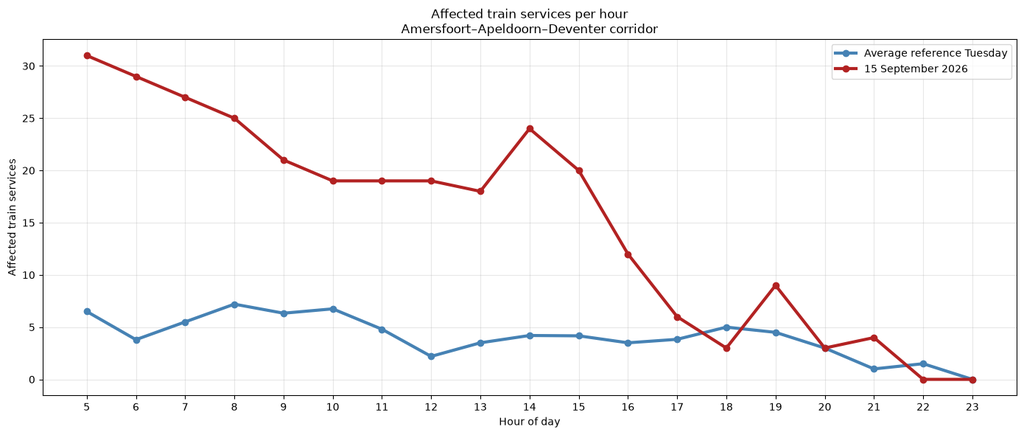

```python
from IPython.display import Image, display

display(
    Image(
        filename="visualizations/Affected_trainservices_baseline_vs_disruption.png",
        width=900
    )
)
```

**Figure 1. Number of affected train services per hour on the Amersfoort–Apeldoorn–Deventer corridor.** The red line shows the number of affected services on 15 September 2026, while the blue line represents the average number of affected services on the three Tuesdays before and the three Tuesdays after the disruption day.

### Road Traffic Conditions

To determine whether the railway disruption affected road traffic, traffic intensity and average speed on the A1 were compared with a baseline constructed from comparable Tuesdays surrounding the disruption day.

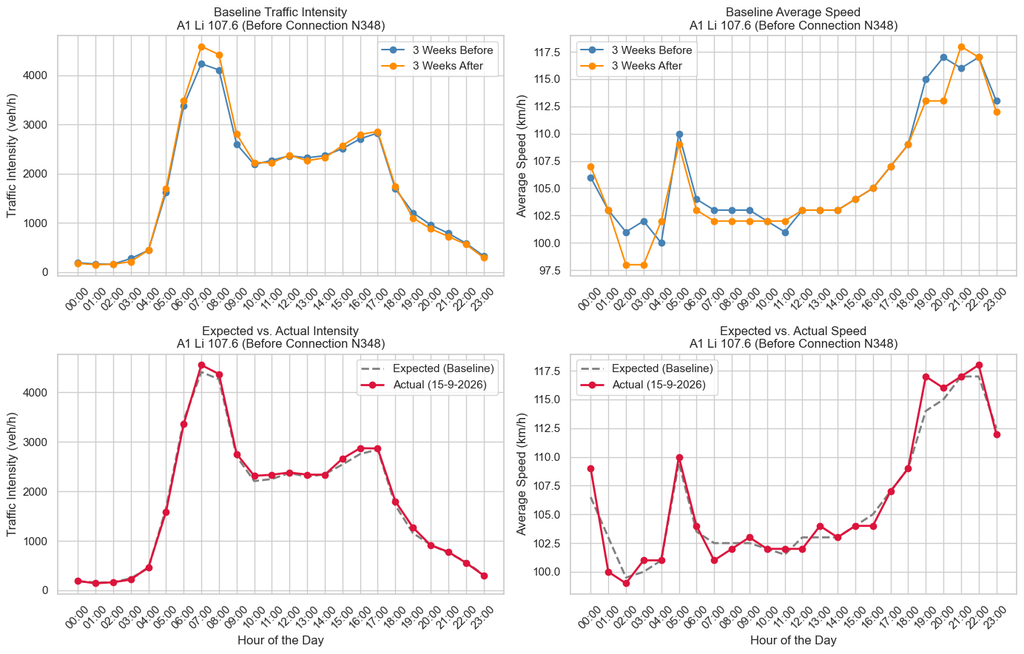

```python
from IPython.display import Image, display

display(
    Image(
        filename="visualizations/Speed_and_intensity_avarage_vs_baseline.png",
        width=900
    )
)
```

**Figure 2. Example of observed and expected traffic conditions on the A1 corridor.** Traffic intensity and average vehicle speed on 15 September 2026 are compared with the baseline values derived from the surrounding Tuesdays. The figure illustrates the extent to which traffic conditions on the disruption day deviated from normal Tuesday traffic patterns.

The traffic intensity measurements generally followed the expected daily pattern, including the typical morning and afternoon peak periods. Although local deviations were observed at several measurement locations, there was no clear corridor-wide increase in traffic intensity relative to the baseline.

Average vehicle speeds also remained close to their expected values throughout most of the day. Some larger deviations were observed near Hoevelaken, where temporary reductions in speed coincided with lower traffic flows. However, these deviations were limited to specific locations and time periods rather than being visible along the entire corridor.

Overall, the traffic data does not indicate a substantial increase in road usage on the A1 corridor during the railway disruption.

### Comparison of Rail and Road Effects

The railway disruption analysis demonstrates that train services on the Amersfoort–Apeldoorn–Deventer corridor were heavily affected throughout the day. In contrast, the traffic data shows only limited deviations from normal traffic conditions on the parallel A1 motorway.

# Conclusion

Despite the severity of the railway disruption, traffic measurements on the A1 motorway showed little evidence of a corresponding increase in road traffic. Traffic intensity and average vehicle speeds generally remained close to their expected values, and no consistent corridor-wide pattern of increased road demand was observed.

The results therefore suggest that the railway disruptions of 15 September 2026 did not lead to a substantial increase in traffic on the studied section of the A1. Although individual travellers may have switched to car travel, the overall effect was too small to be clearly detected in the motorway traffic data.

Within the limitations of the available datasets, this study indicates that even severe railway disruptions do not necessarily translate into measurable increases in motorway traffic.

# Discussion

There was not a clear increase in traffic on the A1 motorway. A possible explanation is that affected travellers did not simply switch from train to car. Instead, they may have postponed their trip, travelled at a different time, used replacement transport or chosen alternative rail routes. Because this study only observes traffic on the A1, these behavioural responses cannot be measured directly.

There are also a few limitations. Traffic conditions can be influenced by many factors, including accidents, roadworks and normal day-to-day fluctuations. Another limitation is that the train service dataset contains information on disrupted services but not on the number of passengers affected by each disruption.

Within the scope of this study, there is little evidence that the railway disruption resulted in a substantial increase in motorway traffic.

Future research could combine train service data with passenger counts or broader mobility datasets to better understand how travellers respond to disruptions in the rail network.

# References

CROW Kennisbank. (n.d.). https://kennisbank.crow.nl/kennismodule/publicationdetail/243#24834

Huang, Z., & Loo, B. P. Y. (2023). Vulnerability assessment of urban rail transit in face of disruptions: A framework and some lessons from Hong Kong. Sustainable Cities and Society, 98, 104858. https://doi.org/10.1016/j.scs.2023.104858

NDW. (n.d.). Dexter open data. Nationaal Dataportaal Wegverkeer. https://dexter.ndw.nu/opendata/overview

NOS. (2026, September 15). Branden in de berm en tientallen sabotageacties op het spoor: een overzicht van de dag. https://nos.nl/artikel/2631176-branden-in-de-berm-en-tientallen-sabotageacties-op-het-spoor-een-overzicht-van-de-dag

Rijden de Treinen. (n.d.). Open Data: Train services dataset. Retrieved from https://www.rijdendetreinen.nl/open-data/treinarchief#downloads

# AI Disclosure Statement

We acknowledge the use of Microsoft Copilot (https://copilot.cloud.microsoft) and Gemini (https://gemini.google/students) in preparing this submission. We used it for the following purposes: Assisting with programming and debugging. Providing feedback on draft or code. Jente has used Copilot to assist her in programming and debugging plots and to clean up NS datasets that had an issue regarding summer- and wintertime. Sipke has used Gemini to improve the structure and readability of the code that is used for visualizing data. We confirm that we have critically reviewed and verified all AI-assisted content, that the submitted work reflects our own understanding, and that we take full responsibility for its accuracy and originality.